# Is Music a Represenatation of Social Movement?

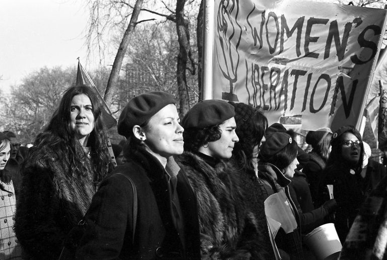

# Introducation

Social movement arise not only in response to conditions of inequality or injustice but, more importantly, because if changing definations of these conditions. In our daily life, we’re closly connected with music. Music can affect our mood in many ways. When we listen to joyful, happy music, our brains usually produce chemicals such as serotonin and dopamine, which make us feel happy. The same happens when we listen to relaxing, soothing music or to hard, loud, angry music that can also cause a number of different emotional feeling. It is true that different music can have difference kind of impact in our mind. However, if you’re in a bad mood, will you become happy after listening to some joyful music? Or maybe, do you even want to choose to listen to happy music in the first place? I believe that answer to this music is no. It seems that we have a habit of choosing music based on the mooods we are already feeling. Using music to express our feeling is not a lastest thing. It has been used to response of conditions of inequality or injustice in the society for decades. For example,“Before the 1970s, a woman couldn’t get a credit card in her own name… and marital rape was not a thing,”said Sara Bijani, Ph.D. candidate in contemporary U.S history at Michigan State University. In late 1960’s and early 1970’s, it became evident that ignoring the impact of popular music on social and cultural protest movements was sociological folly@[Merriam1964].Moreover, as @[Finlay1980] has noted that if one examines just the lyrics of protest songs asscociated with social movements, one can find many examples of diagnoses of what is worng with the present order of things, proposed soluations to these wrongs, and rationales for participation in the movement, as those were key elements in the ideology.

Here comes my analysis of the lyriscs to find out what does people talks about the most during that time, and what are the sentiments inside these lyrics.

```r
library(tidyverse)
library(tidytext)
library(plotly)
library(DT)
library(tm)
library(data.table)
library(scales)
library(wordcloud)
library(wordcloud2)
library(ngram)
library(shiny)
library(textdata)
library(GGally)
load('../output/processed_lyrics.RData')
```

```r
#Create a list of time data.
dt_lyrics <- dt_lyrics %>%
  mutate(time_list = case_when(
    year >= 1970 & year < 1980 ~ "1970s",
    year >= 1980 & year < 1990 ~ "1980s",
    year >= 1990 & year < 2000 ~ "1990s",
    year >= 2000 & year < 2010 ~ "2000s",
    year >= 2010 & year < 2020 ~ "2010s"
  ))
dt_lyrics$time_list <- as.factor(dt_lyrics$time_list)
#Update Stop_words, such as ill,ive and youre, that encountered most from EDA.
custome_stop_words <- tribble(
  ~word,~lexicon,
  "ill", "custom",
  "ive", "custom",
  "youre","custom",
  "love", "custom")
stop_words2 <-stop_words%>%
  bind_rows(custome_stop_words)
#reprocressed data with new stop-words2.
lyrics <- dt_lyrics %>%
  select(id,genre, time_list, stemmedwords) %>%
  unnest_tokens(word, stemmedwords) %>%
  anti_join(stop_words2)
```

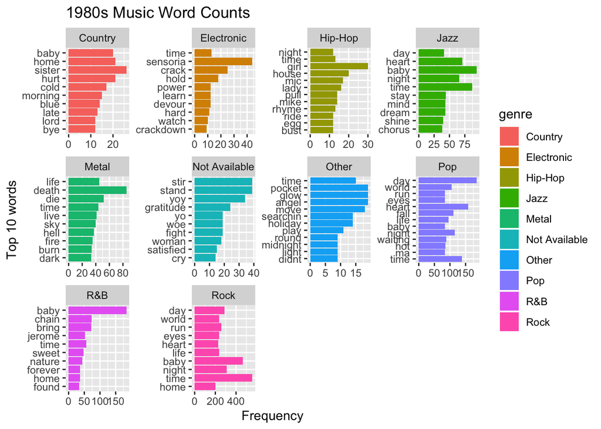

```r
  lyrics %>%
  filter(time_list == "1980s") %>%
  count(genre,word) %>%
  group_by(genre)%>%
  top_n(10,n) %>%
  ungroup() %>%
  mutate(word2 = fct_reorder(word,n)) %>%
 ggplot(aes(x = word2, y = n, fill = genre)) +
        ylab("Frequency") +
        xlab("Top 10 words")+
         geom_col() +
         facet_wrap(~ genre ,scales = "free") +
        coord_flip() +
  ggtitle("1980s Music Word Counts")
```

This is a graph of top 10 words that appeared the most during 1980s for different kind of genre. So, we can see that the most singing word in Country amd Hip-Hop are both related to women. So, the question came to my mind that is this always the case or just during in this decade. Next,I plotted the most common words that used last decades for those two genres in wordcloud and trying to find the dramatic changes.

## WordCloud

```r
word_counts__HipHop_country_1970 <- lyrics %>%
  filter(genre == "Country" |genre == "Hip-Hop") %>%
  filter(time_list == "1970s") %>%
  count(word) %>%
  arrange(desc(n))
wordcloud2(word_counts__HipHop_country_1970,
           color = "random-light",
           shape = "circle",
           gridSize = 0.7)
```

[interactive chart not shown]

From wordcloud, we can see that people actually mention more about the time and life, which implies that there is a dramatic from 1970s to 1980s, from “time” to “sister or girl”. Accompanied with this word, there’re more words like hurt, cold appearning in 1980s as well, which might be an indication of the movement is at its peak at that time. So what is the sentiment during this period. In sociology study, there are three major components associated with social movement.

- “Social discontent” just like women libeartion movement, people are not content with their “stereotype” at home.
- Those social conditions are not unchangable, which means they can actually do the same thing as man, and that’s why this image came out.

[figure not shown]

- The goal of this moevment that must be the common values of larger population in which the movement is operating @[Spector&Kitsuse1977] Accoording to the above analysis, we’re expecting that the sentiment will be generally sadness, fear and anger. Let us see is this true or not.

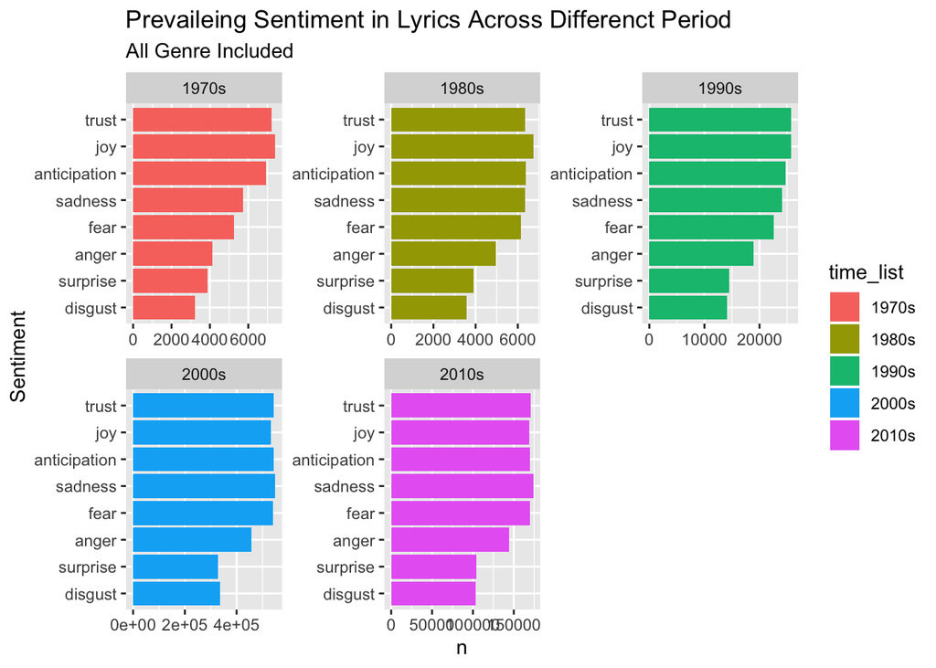

```r
##all genre sentiment analysis
Music_word_sentiment <- lyrics %>%
inner_join(get_sentiments("nrc"))%>%
  drop_na(time_list)%>%
  count(time_list,sentiment) %>%
  filter(sentiment %in% c("anger","anticipation","disgust","sadness","surprise","fear","trust","joy"))%>%
  group_by(time_list)%>%
  top_n(10,n) %>%
  ungroup() %>%
  mutate(sentiment2 = fct_reorder(sentiment,n))
ggplot(Music_word_sentiment, aes(x = sentiment2, y = n, fill = time_list)) +
         geom_col(show.legend = TRUE)+
         coord_flip() +
        facet_wrap(~time_list, scales = "free")+
        labs(
          title = "Prevaileing Sentiment in Lyrics Across Differenct Period",
          subtitle = "All Genre Included ",
          x = "Sentiment"
        )
```

However, this graph is not an actual representation, as we can clearly see n can range from several hundred thousands to several thousands, so it is not comparable for different period. Moreover, as time goes on later period have more words than former, we were not able to tell is there an overall increase in some semtiment or not, as data is not standardized. Here comes my line plot which standardized and also take out those not strong emotions like positive and negative.

## Prevaileing Sentiment in Line Plot

[figure not shown]

```r
lyrics %>%
inner_join(get_sentiments("nrc"))%>%
  filter(genre == "Country") %>%
  drop_na(time_list)%>%
  count(time_list,sentiment) %>%
  group_by(time_list)%>%
  ungroup() %>%
  filter(sentiment %in% c("anger","anticipation","disgust","sadness","surprise","fear","trust","joy"))%>%
  mutate(sentiment2 = fct_reorder(sentiment,n)) %>%
  mutate(percentage = n/sum(n)) %>%
  select(-n) %>%
  spread(time_list, percentage) %>%
  ggparcoord(columns = 3:7, groupColumn = 1) +
        labs(
          title = "Prevaileing Sentiment in Lyrics Across Differenct Period",
          subtitle = "All Genre Included ",
          x = "Time",
          y = "standardized Value")
```

We found out there is an increase in sadness, fear, and anger from 1970s to 1980s and the anticipation of was decreased as well. This also proved that the discontent in the society have been grown, the first condition of the social movement. That’s however, not enought to start a movement, and it must be able to cover enought population. One more thing nice to notice that, during 1970-1980s, the American economy was suffering through a deep recession. The uncertainity of financial casued them to acquire the right that they don’t have before, such as ending discrimination, in order to get financial independent.

# Summary:

Art is a representation of the society, it can help to make the society better, just like the role of music in women liberation movement. Becaused of the hardword those people did in the past, nowadays, women are having the same right as men. The important of music is it can give the power of public opinion, and therefore the analysis of lyrics, what the song is writing about, can give us an idea, what is going on in that period just like what history did.

# Reference:

FINLAY, Barbara, 1980 Nationalosm In Musical Protest. Unpublished. Cowallis: Oregon

MERRIAM, Alan P, 1964 The Athropology of Music, Evanston: Northwestern Univ. Press

SPECTOR, Malcolm & J. KITSUSE, 1977 Constructing Social Problems. Menlo Park, Ca.: Cummings